# FINALLLLSL

Gianna Cannek

2025-05-14

1. Research question: What weather observations are the best predictors for increased wildfire start risk in California?

I am using data from an engineered data set that combines meteorological data from NOAA Climate Data Online with fire incident data from CAL FIRE. Specifically, it is the compilation of weather observations and wildfire data in California from 1984 to 2025.

The variables used are defined below: DATE: The date of the observation. PRECIPITATION: Daily precipitation in inches. MAX_TEMP: Maximum daily temperature in degrees Fahrenheit. MIN_TEMP: Minimum daily temperature in degrees Fahrenheit. AVG_WIND_SPEED: Average daily wind speed in mph. FIRE_START_DAY: A binary indicator (True/False) showing whether a wildfire started on that date. YEAR: The year of the observation. TEMP_RANGE: The difference between maximum and minimum temperatures, indicating daily temperature variability. WIND_TEMP_RATIO: The ratio of average wind speed to maximum temperature, capturing wind-temperature dynamics. MONTH: The calendar month of the observation (1–12). SEASON: The season of the observation (Winter, Spring, Summer, Fall). LAGGED_PRECIPITATION: Cumulative precipitation over the preceding 7 days, reflecting recent moisture conditions. LAGGED_AVG_WIND_SPEED: Average wind speed over the preceding 7 days, indicating sustained wind patterns. DAY_OF_YEAR: The numeric day within the year (1–365/366).

’’’ Select a supervised learning algorithm that we haven’t discussed in class, and teach the reader how your chosen algorithm works in the context of your data: ’’’

2. One supervised learning algorithm that has not been discussed in class and would be helpful is Support Vector Machines (SVMs). This algorithm works by finding the best line or hyper plane that separates data into groups, maximizing the distance between the closest points of each group (support vectors). When the data is not linearly separable, kernel functions, which maps data into a higher-dimensional space, are used to transform the data higher-dimensional space to enable linear separation. Kernel functions allow SVMs to operate in a higher-dimensional space by computing relationships between data points, enabling linear separation even when the original data is not linearly separable. SVM finds a hyperplane that is equidistant from the support vectors of each class, thus maximizing the margin. The margin is the space between the two dashed lines on either side of the separating hyperplane. Support vectors are the points that lie directly on these margins.

I’ve included a simple example using fake data to show how this works.

```r
library(ggplot2)
```

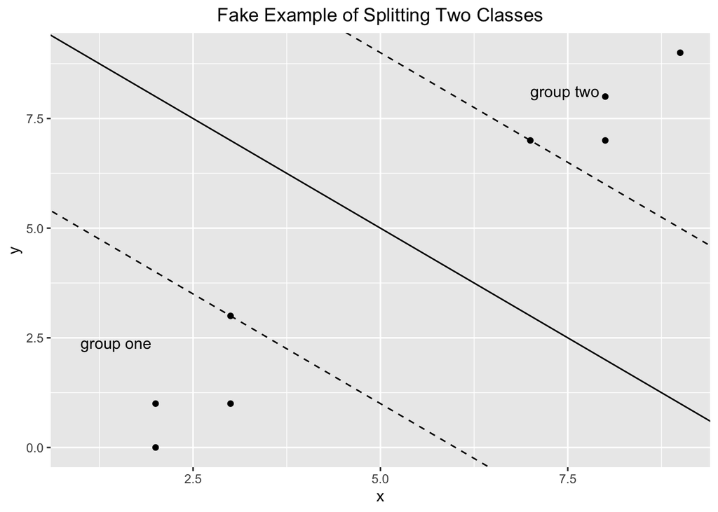

```r
svm_data <- data.frame(
  x = c(2, 8, 2, 3, 3, 9, 8, 7),
  y = c(0, 7, 1, 3, 1, 9, 8, 7))


svm_data |>
  ggplot(aes(y = y, x = x)) +
  geom_point() +
  geom_abline(slope = -1, intercept = 10) +
  geom_abline(slope = -1, intercept = 6, lty = 2) +
  geom_abline(slope = -1, intercept = 14, lty = 2) +
  labs(title = "Fake Example of Splitting Two Classes") +
  theme(plot.title = element_text(hjust = 0.5)) +
  annotate("text", x = 1, y = 2.25, label = "group one", hjust = 0, vjust = 0) +
  annotate("text", x = 7, y = 8, label = "group two", hjust = 0, vjust = 0)
```

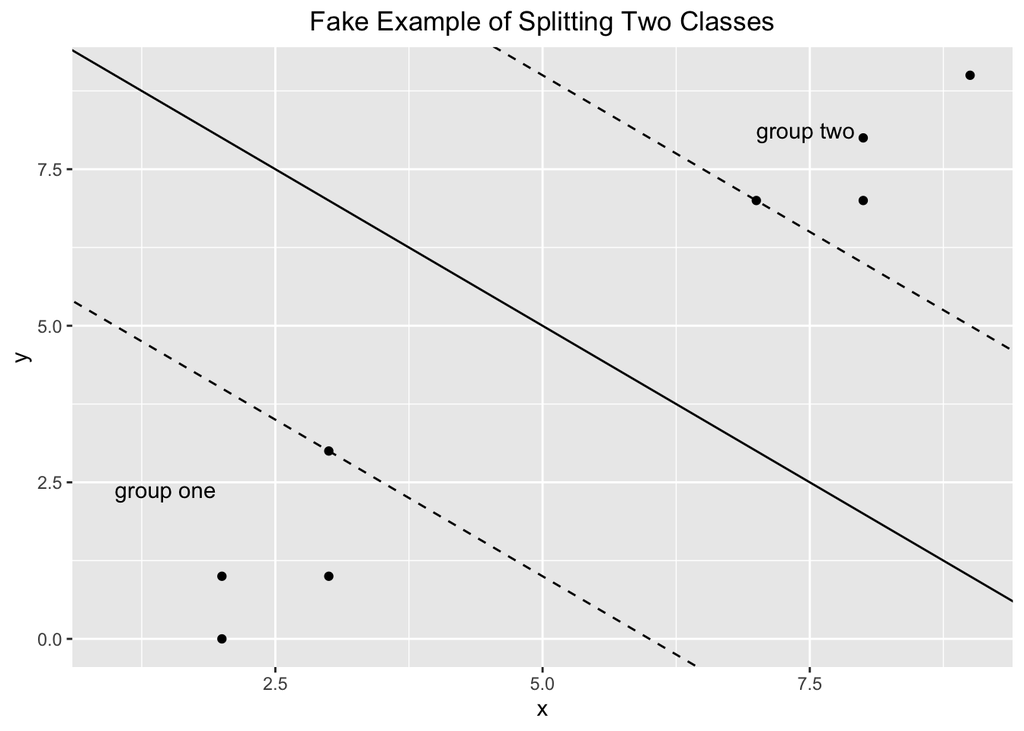

```r
svm_data |>
  ggplot(aes(y=y, x=x))+
  geom_point()+
  geom_abline(slope = -1, intercept = 10) +
  geom_abline(slope = -1, intercept = 6, lty = 2) +
  geom_abline(slope = -1, intercept = 14, lty = 2) +
  labs(title = "Fake Example of Splitting Two Classes") +
  theme(plot.title = element_text(hjust=0.5)) +
  annotate("text", x = 1, y = 2.25, label = "group one", hjust = 0, vjust = 0) +
  annotate("text", x = 7, y = 8, label = "group two", hjust = 0, vjust = 0)
```

The black line represents the decision boundary, and the two dotted lines represent the margins. The points at (3, 3) and (7, 7) lie on these margins—they are the support vectors. These support vectors are the most “influential” points for determining the boundary. Any new point above the black line would be classified as “group two”, and anything below it as “group one”.

I chose this algorithm in the context of the wildfire data because I am trying to predict binary classes (if a fire started that day or not) and Support Vector Machines does this very well. Since Support Vector Machines perform well with high-dimensional data, they are a good fit for this application involving many weather-related predictors. I would train an Support Vector Machines using this data to classify days as “fire” or “no fire” based on multiple meteorological variables. In my data set I could use variables such as precipitation, maximum temperature, or lagged average wind speed as inputs to predict if a fire started or not. To evaluate my precision I could chop my data in half into a training data set and a testing data set and then test the model crated on training set on the testing data set.

2. Addressing my research question:

My first step into my investigation is to read in the data set and look at if there is missing data in any rows.

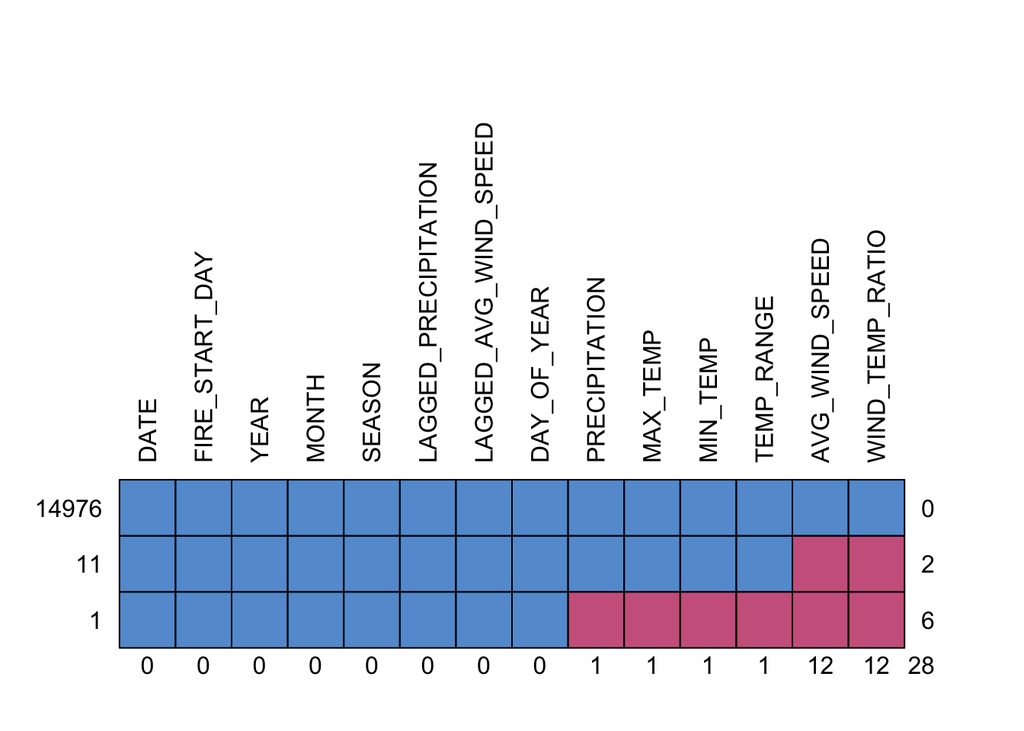

```r
wildfire<- read.csv("/Users/giannacannek/Desktop/statistical learning/FINAL/CA_Weather_Fire_Dataset_1984-2025.csv")
md.pattern(wildfire, rotate.names = TRUE)
```

According to this pattern there are 14976 rows of no missing cells, 11 rows with 2 missing variables (average wind speed and wind temperature ratio), and 1 row of 6 missing variables (precipitation, maximum temperature, minimum temperature, average wind speed, and wind temperature ratio. This is a very small fraction of the data so it should not change my analysis by a lot, but it doesn’t hurt to fill in the missing data. Lets complete the data set by using a random forest! By doing this I am calculating what a missing value should be using the known variables. In this case I picked a random forest which is a combination of multiple flowchart-like models that makes predictions based on a series of decisions.

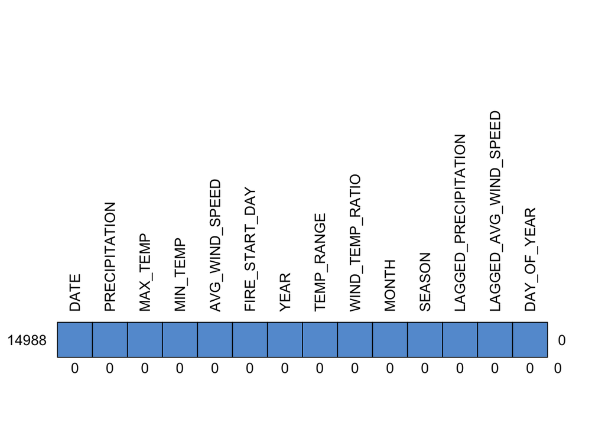

```r
imputed_wildfires <- mice(wildfire,
                         method = "rf",
                         seed = 1)
wildfires <- complete(imputed_wildfires) ##WILDFIRE CHANGES TO WILDFIRES HERE
md.pattern(wildfires, rotate.names = TRUE)
```

Now that all the values are estimated in, I am going to do some analysis on how wildfire patterns have changed over time. I also decided to trim the months of 2025 before analysis because there was no full seasonal cycle recorded in that year.

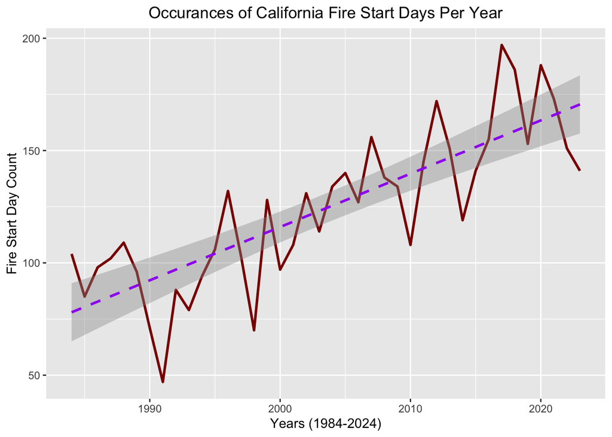

```r
wildfires<- wildfires |>
  filter(YEAR <= 2024)

count_type_per_year<- wildfires |> group_by(YEAR) |> count(FIRE_START_DAY)

count_type_per_year |>
  filter(FIRE_START_DAY == "True") |>
  ggplot(aes(x = YEAR, y = n)) +
  geom_line(color = "darkred", linewidth = 1) +
  stat_smooth(method = "lm", formula = y ~ x, color = "purple",  lty = 2)+
  labs(title = "Occurances of California Fire Start Days Per Year", x = "Years (1984-2024)", y= "Fire Start Day Count") +
  theme(plot.title = element_text(hjust=0.5))
```

According to the trend line it looks like days that the number of fire start days in California are generally increasing over time. Although many factors go into a fire and not all fires are from weather events, I am curious to see if any weather events are also increasing and helping create the right conditions for wildfire risk. First I am going to look at maximum and minimum temperatures over years.

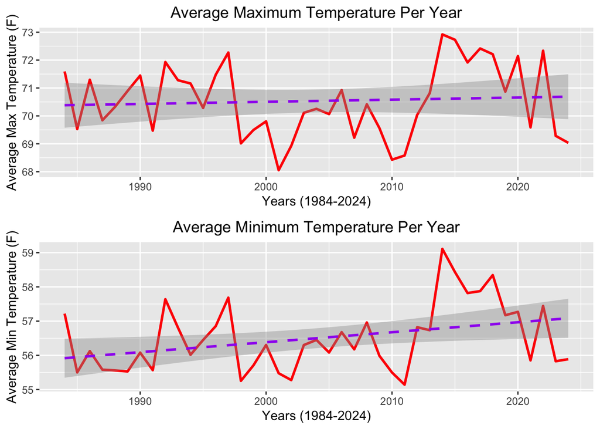

```r
avg_max_temp<- wildfires|> group_by(YEAR) |> dplyr::summarize(avg_max_temp = mean(MAX_TEMP))

first<- avg_max_temp|>
  ggplot(aes(x = YEAR, y = avg_max_temp)) +
  geom_line(aes(y = avg_max_temp), color = "red",  linewidth = 1)  +
  labs(title = "Average Maximum Temperature Per Year", y= "Average Max Temperature (F)", x = "Years (1984-2024)") +
theme(plot.title = element_text(hjust=0.5)) +
  stat_smooth(method = "lm", formula = y ~ x, color = "purple",  lty = 2)

avg_min_temp<- wildfires|> group_by(YEAR) |> dplyr::summarize(avg_min_temp = mean(MIN_TEMP))

second<- avg_min_temp|>
  ggplot(aes(x = YEAR, y = avg_min_temp)) +
  geom_line(aes(y = avg_min_temp), color = "red",  linewidth = 1)  +
  labs(title = "Average Minimum Temperature Per Year", y= "Average Min Temperature (F)", x = "Years (1984-2024)") +
theme(plot.title = element_text(hjust=0.5)) +
  stat_smooth(method = "lm", formula = y ~ x, color = "purple",  lty = 2)

grid.arrange(first,second,  ncol = 1)
```

It looks like the average maximum temperature per year is staying mostly consistent and the average minimum temperature per year is increasing. In a wildfire course I took at Middlebury, I learned that the temperature at night is a very important factor for wilfires so this factor would be a really good predictor as my first guess. A hot night time temperature can dry out vegetation and cant suprress an already burning fire as well. I am going to do the same graphing for average lagged wind speed and average lagged precipitation to see if the conditions that reflected recent moisture conditions and sustained wind patterns have the same trend.

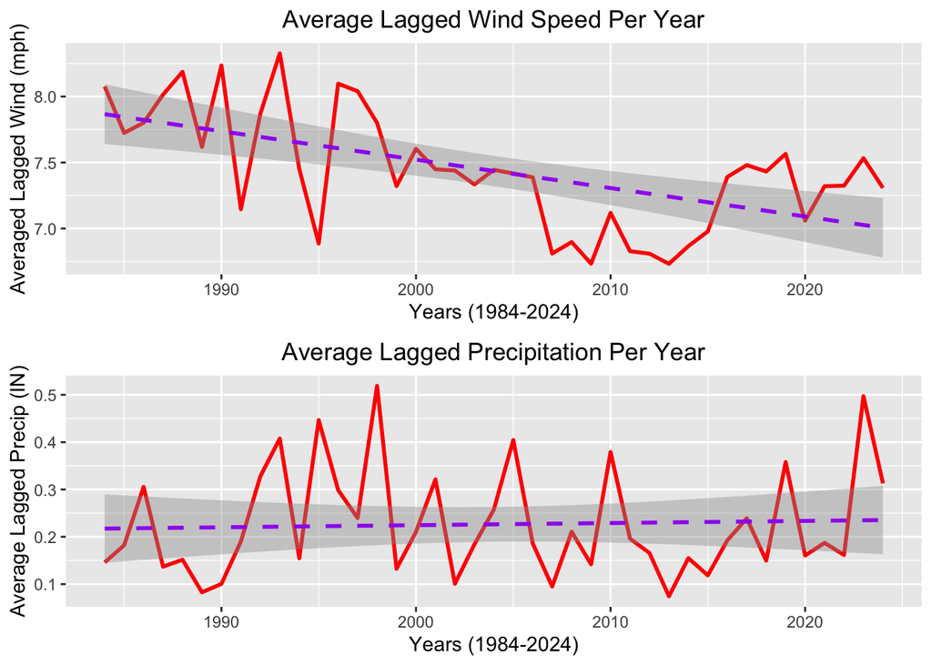

```r
avg_lagged_wind<- wildfires|> group_by(YEAR) |> dplyr::summarize(avg_lagged_wind = mean(LAGGED_AVG_WIND_SPEED))

first1<- avg_lagged_wind|>
  ggplot(aes(x = YEAR, y = avg_lagged_wind)) +
  geom_line(aes(y = avg_lagged_wind), color = "red",  linewidth = 1)  +
  labs(title = "Average Lagged Wind Speed Per Year", y= "Averaged Lagged Wind (mph)", x = "Years (1984-2024)") +
theme(plot.title = element_text(hjust=0.5)) +
  stat_smooth(method = "lm", formula = y ~ x, color = "purple",  lty = 2)

avg_lagged_precip<- wildfires|> group_by(YEAR) |> dplyr::summarize(avg_lagged_precip = mean(LAGGED_PRECIPITATION))

second2<- avg_lagged_precip|>
  ggplot(aes(x = YEAR, y = avg_lagged_precip)) +
  geom_line(aes(y = avg_lagged_precip), color = "red",  linewidth = 1)  +
  labs(title = "Average Lagged Precipitation Per Year", y = "Average Lagged Precip (IN)", x = "Years (1984-2024)") +
theme(plot.title = element_text(hjust=0.5)) +
  stat_smooth(method = "lm", formula = y ~ x, color = "purple",  lty = 2)

grid.arrange(first1,second2,  ncol = 1)
```

It looks like the average lagged wind speed per year is generally decreasing and lagged precipitation is staying the same overall. I am now going to compare when fire start days occur seasonally to other factors such as maximum temperature, minimum temperature, wind speed, and precipitation to understand their seasonal relationship.

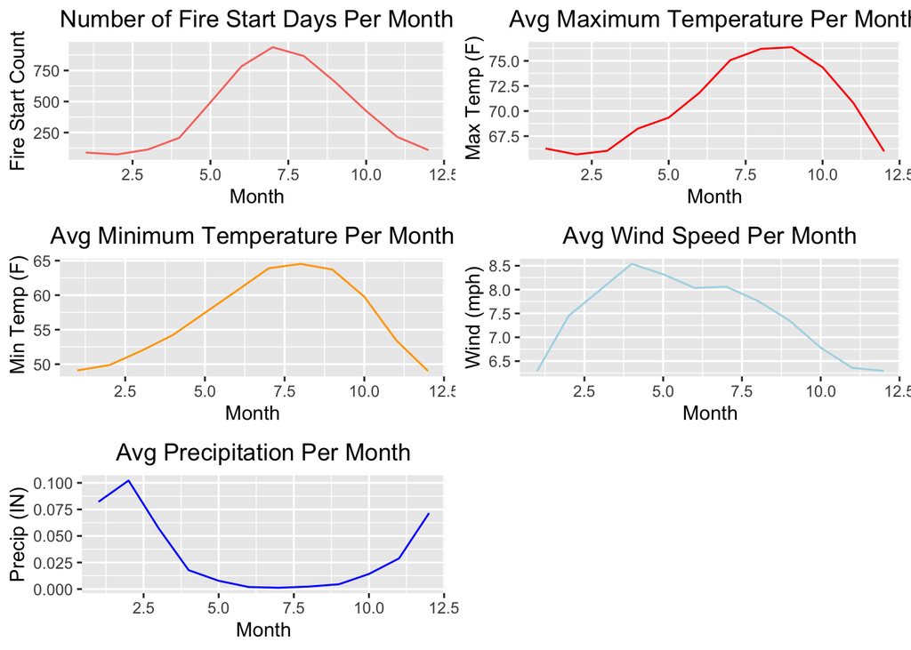

```r
count_type_per_month<- wildfires |> group_by(MONTH) |> count(FIRE_START_DAY)

plot1<- count_type_per_month |> group_by(FIRE_START_DAY) |>
  filter(FIRE_START_DAY == "True") |>
  ggplot() +
  geom_line(mapping = aes(x= MONTH,
                          y=n, color=FIRE_START_DAY, fill= "darkred")) +
  guides(color = "none")   +
  labs(title = "Number of Fire Start Days Per Month", x = "Month", y= "Fire Start Count") +
theme(plot.title = element_text(hjust=0.5))
avg_max_temp<- wildfires|> group_by(MONTH) |> dplyr::summarize(avg_max_temp = mean(MAX_TEMP))

plot2<-   ggplot(avg_max_temp, aes(x=(MONTH))) +
  geom_line(aes(y = avg_max_temp), color = "red")  +
  labs(title = "Avg Maximum Temperature Per Month", y= " Max Temp (F)", x = "Month") +
theme(plot.title = element_text(hjust=0.5))

avg_min_temp<- wildfires|> group_by(MONTH) |> dplyr::summarize(avg_min_temp = mean(MIN_TEMP))

plot3<-   ggplot(avg_min_temp, aes(x=(MONTH))) +
  geom_line(aes(y = avg_min_temp), color = "orange")  +
  labs(title = "Avg Minimum Temperature Per Month", y= " Min Temp (F)", x = "Month") +
theme(plot.title = element_text(hjust=0.5))

avg_wind<- wildfires|> group_by(MONTH) |> dplyr::summarize(avg_wind = mean(AVG_WIND_SPEED))

plot4<-   ggplot(avg_wind, aes(x=(MONTH))) +
  geom_line(aes(y = avg_wind), color = "lightblue")  +
  labs(title = "Avg Wind Speed Per Month", x= "Month", y= "Wind (mph)") +
theme(plot.title = element_text(hjust=0.5))

avg_precip<- wildfires|> group_by(MONTH) |> dplyr::summarize(avg_precip= mean(PRECIPITATION))

plot5<-   ggplot(avg_precip, aes(x=(MONTH))) +
  geom_line(aes(y = avg_precip), color = "blue")  +
  labs(title = "Avg Precipitation Per Month", x= "Month", y= "Precip (IN)") +
theme(plot.title = element_text(hjust=0.5))

grid.arrange(plot1, plot2, plot3,plot4, plot5, ncol = 2)
```

From this visualization it looks like fire start days follow a similar seasonal relationship to minimum and maximum temperature and an inverse seasonal relationship to precipitation. Number of fires per month peaks when average wind speed is moderate.

My first statistical learning technique will be a classification decision tree to understand the importance of different variables. Decision trees recursively split data based on the most informative features and create nodes that represent decision points and leaf nodes that represent the final classification. In this case weather factors are the informative features and the final classification is if it will be a fire start day or not. For this I took out all temporal variables such as date, season, and year because those are not weather related variables.

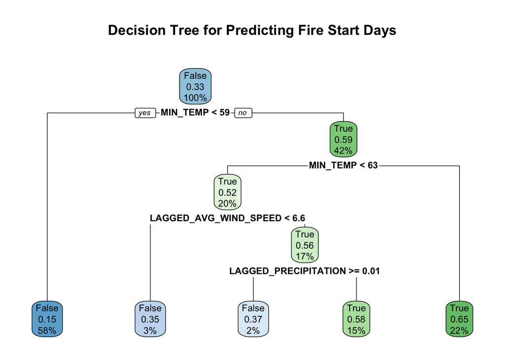

```r
no_date_wildfire <- wildfires |>
  dplyr::select(PRECIPITATION,MAX_TEMP, MIN_TEMP, AVG_WIND_SPEED, FIRE_START_DAY, TEMP_RANGE, WIND_TEMP_RATIO, LAGGED_PRECIPITATION,LAGGED_AVG_WIND_SPEED)

wildfires_tree <- rpart( FIRE_START_DAY ~ .,
                  data = no_date_wildfire)
rpart.plot(wildfires_tree, main = "Decision Tree for Predicting Fire Start Days")
```

Decision tree performs well in predicting most classes, but may struggle with classes that have similar characteristics in their data. I am going to make a boosted decision tree which is an ensemble learning method that combines a set of weak learners (decision trees with less splits) into a strong learner to minimize training errors. I chose some variables that showed up in the decision trees plus maximum temperature to understand their relationship more clearly and then visualized how important their values are in predicting fire start days.

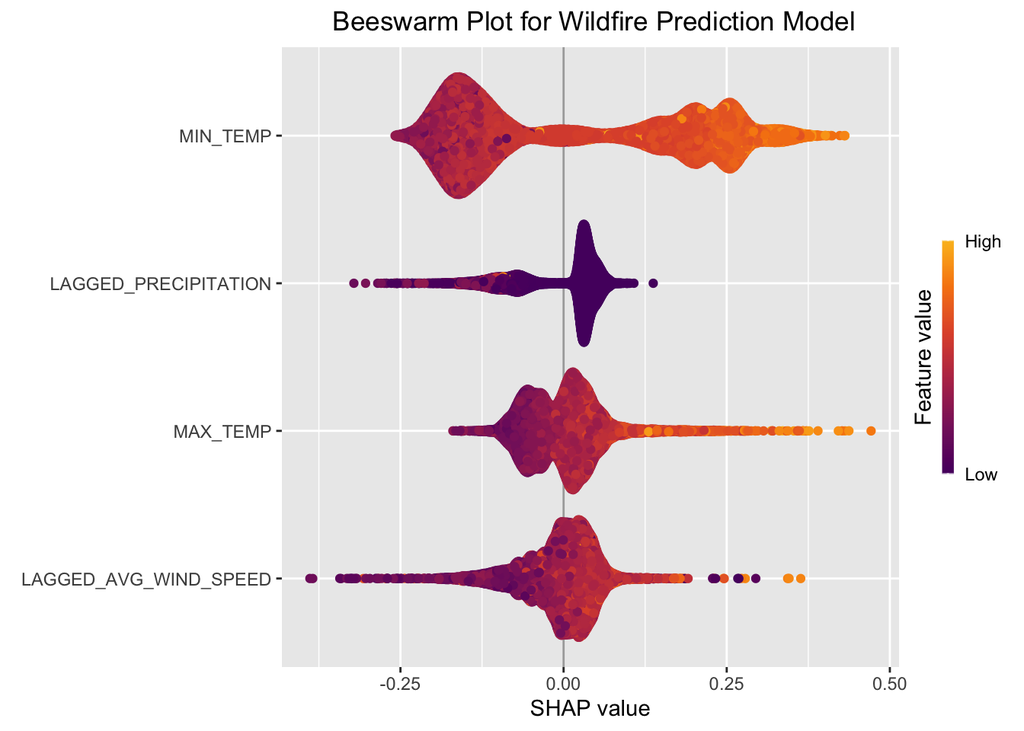

```r
set.seed(1)

wildfire_subset <- wildfires |>
  dplyr::select(MAX_TEMP, MIN_TEMP, LAGGED_PRECIPITATION,LAGGED_AVG_WIND_SPEED)

wildfire_subset <- wildfires |>
  dplyr::select(MAX_TEMP, MIN_TEMP, LAGGED_PRECIPITATION, LAGGED_AVG_WIND_SPEED)

label_numeric <- as.numeric(wildfires$FIRE_START_DAY == "True")

boost_data <- xgb.DMatrix(data.matrix(wildfire_subset), label = label_numeric)

boost_model <- xgb.train(data = boost_data,
                         nrounds = 100,
                         params = list(
                           learning_rate = 0.1,
                           objective = "reg:squarederror"
                         ))

shap_values <- shapviz(boost_model,
                       X_pred = data.matrix(wildfire_subset),
                       X = wildfire_subset)


sv_importance(shap_values, kind = "beeswarm") +
  ggtitle(" Beeswarm Plot for Wildfire Prediction Model")+
  theme(plot.title = element_text(hjust=0.5))
```

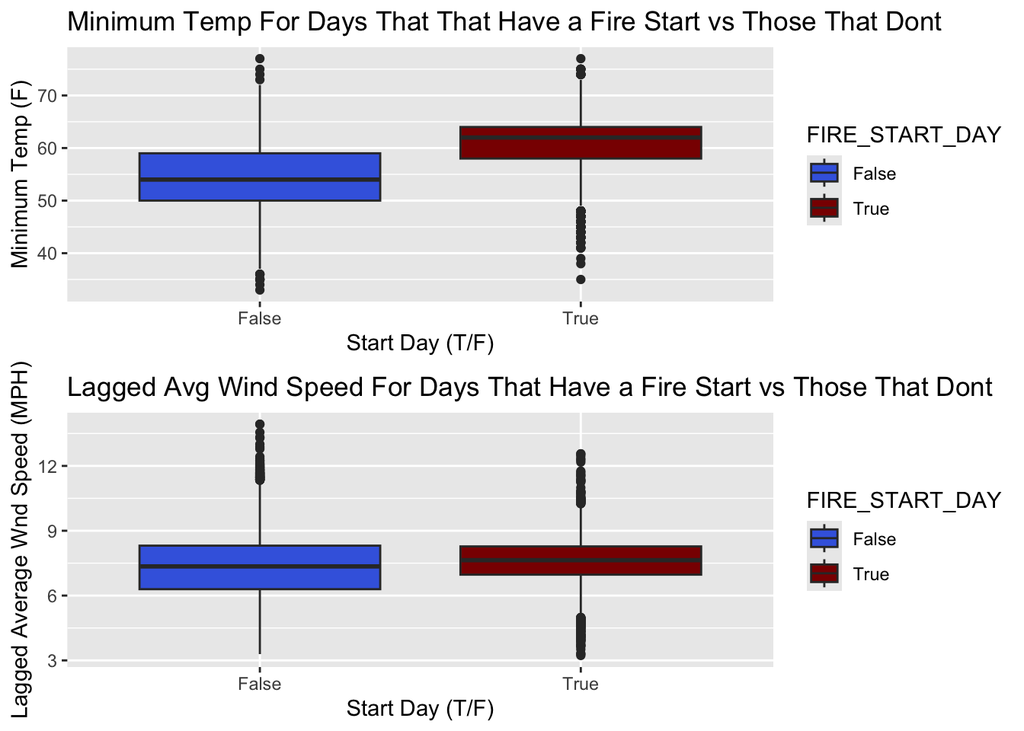

```r
custom_colors <- c("royalblue", "darkred")

plottt1<- wildfires |>
  ggplot(aes(x = FIRE_START_DAY, y = MIN_TEMP, fill = FIRE_START_DAY)) +
  geom_boxplot() +
  scale_fill_manual(values = custom_colors)+
  labs(title = "Minimum Temp For Days That That Have a Fire Start vs Those That Dont",
       y = "Minimum Temp (F)",
       x = "Start Day (T/F)")

plottt2<-wildfires |>
  ggplot(aes(x = FIRE_START_DAY, y = LAGGED_AVG_WIND_SPEED, fill = FIRE_START_DAY)) +
  geom_boxplot() +
  scale_fill_manual(values = custom_colors)+
  labs(title = "Lagged Avg Wind Speed For Days That Have a Fire Start vs Those That Dont",
       y = "Lagged Average Wnd Speed (MPH)",
       x = "Start Day (T/F)")

grid.arrange(plottt1, plottt2, ncol = 1)
```

This agrees with what I have been noticing in other visualizations and models for higher minimum temperatures as high minimum temperatures are more correlated with fire start days. It looks like overall an higher average wind speed is only slightly correlated with fire start days, but their relationship might not be as linear as minimum temperature and that’s why the average wind speed is not going to show much in a box plot.

I am going to make one last model to understand the relationship between minimum temperature and lagged average wind speed with Linear discriminant analysis (LDA). LDA separates multiple classes with multiple features through data dimensionality reduction. In this case I want to collapse the dimensionality of minimum temperature and lagged average wind speed with fire start day. I can then find how aaccurate my LDA model is by splitting the data in half with equal training and testing data sets.

```r
set.seed(1)
shuffled_wf= wildfires[sample(1:nrow(wildfires)), ] #shuffling data

training_rows <- sample(1:nrow(shuffled_wf), size = nrow(shuffled_wf)/2)

training <- shuffled_wf[training_rows, ]
testing <- shuffled_wf[-training_rows, ]

lda_test <- lda(FIRE_START_DAY ~ MIN_TEMP + LAGGED_AVG_WIND_SPEED , data = training)

test_preds <- predict(lda_test, testing)

xtab <- table(test_preds$class, testing$FIRE_START_DAY)
xtab
```

```
##
##         False True
##   False  4206 1176
##   True    757 1349
```

```r
confusionMatrix(xtab)
```

```
## Confusion Matrix and Statistics
##
##
##         False True
##   False  4206 1176
##   True    757 1349
##
##                Accuracy : 0.7419
##                  95% CI : (0.7318, 0.7517)
##     No Information Rate : 0.6628
##     P-Value [Acc > NIR] : < 2.2e-16
##
##                   Kappa : 0.3979
##
##  Mcnemar's Test P-Value : < 2.2e-16
##
##             Sensitivity : 0.8475
##             Specificity : 0.5343
##          Pos Pred Value : 0.7815
##          Neg Pred Value : 0.6406
##              Prevalence : 0.6628
##          Detection Rate : 0.5617
##    Detection Prevalence : 0.7188
##       Balanced Accuracy : 0.6909
##
##        'Positive' Class : False
##
```

```r
every_person_ever_grid <- expand.grid(MIN_TEMP = seq(from = 33, to = 77, by = 5),
                                      LAGGED_AVG_WIND_SPEED = seq(from = 3.227143, to = 13.93286, by = 1))

grid_preds <- predict(lda_test, every_person_ever_grid)

yes_probs <- grid_preds$posterior[,2]

library(viridis)
```

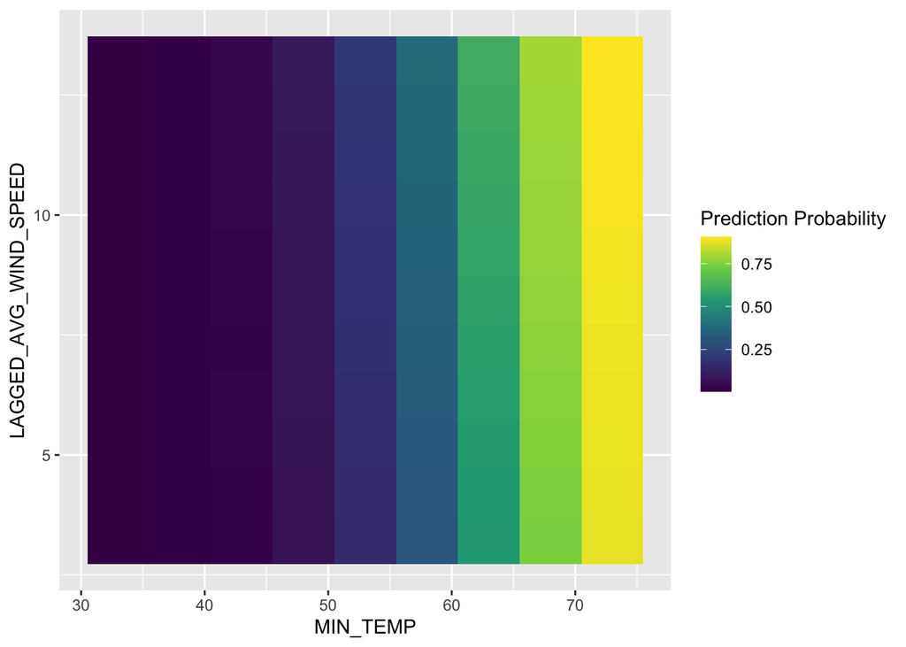

```r
every_person_ever_grid |>
  mutate(predictions = yes_probs) |>
  ggplot() +
  geom_tile(aes(x = MIN_TEMP,
                y = LAGGED_AVG_WIND_SPEED,
                fill = predictions)) +
  scale_fill_viridis_c(option = "D", direction = 1) +
  labs(fill = "Prediction Probability")
```

Overall, high minimum temperature values, and moderate to slightly above average wind speed and less lagged precipitation are the best predictors of increased wildfire risk.